# Coursera Practical Machine Learning Final Project

Daniel

Sunday, February 28, 2016

# Background and Introduction

Using devices such as Jawbone Up, Nike FuelBand, and Fitbit it is now possible to collect a large amount of data about personal activity relatively inexpensively. These type of devices are part of the quantified self movement - a group of enthusiasts who take measurements about themselves regularly to improve their health, to find patterns in their behavior, or because they are tech geeks. One thing that people regularly do is quantify how much of a particular activity they do, but they rarely quantify how well they do it. In this project, your goal will be to use data from accelerometers on the belt, forearm, arm, and dumbell of 6 participants. They were asked to perform barbell lifts correctly and incorrectly in 5 different ways. More information is available from the website here: http://groupware.les.inf.puc-rio.br/har (see the section on the Weight Lifting Exercise Dataset).

The goal of your project is to predict the manner in which they did the exercise. This is the “classe” variable in the training set. You may use any of the other variables to predict with. You should create a report describing how you built your model, how you used cross validation, what you think the expected out of sample error is, and why you made the choices you did. You will also use your prediction model to predict 20 different test cases.

# Datasets Preparation

First of all, we need to install the following packages we use for this project.

```r
library(caret);
library(rattle);library(rpart);
```

```r
library(rpart.plot);library(randomForest);library(forecast);library(e1071);
```

Now we import the datasets from the links:

```r
training=read.csv("https://d396qusza40orc.cloudfront.net/predmachlearn/pml-training.csv",na.strings=c("NA","","#DIV/0!"))
testing=read.csv("https://d396qusza40orc.cloudfront.net/predmachlearn/pml-testing.csv",na.strings=c("NA","","#DIV/0!"))
```

Since we find that the first 7 columns such as names and windows don’t affect the prediction model, we can remove them by the following steps.

```r
training=training[,8:160]
testing=testing[,8:160]
```

Also, we need to remove the columns that has any NA, blank and strange strings values.

```r
training=training[,colSums(is.na(training))==0]
testing=testing[,colSums(is.na(testing))==0]
```

# Data splitting

In order to get out-of-sample error, we need to separate the data into two parts. Here we split the clean training data into a training set(70%) and a validation set(30%).

```r
intrain=createDataPartition(training$classe,p=0.7,list=F)
traindat=training[intrain,]
testdat=training[-intrain,]
```

# Prediction Algorithms

## Classification Tree

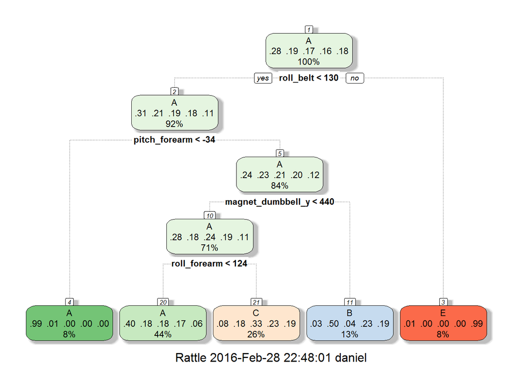

```r
modc=train(classe ~ .,method="rpart",data=traindat,trControl=trainControl(method="cv",number=20))
fancyRpartPlot(modc$finalModel)
```

```r
pred_val=predict(modc,testdat)
confusionMatrix(testdat$classe,pred_val)
```

```
## Confusion Matrix and Statistics
##
##           Reference
## Prediction    A    B    C    D    E
##          A 1521   19  127    0    7
##          B  452  391  296    0    0
##          C  468   29  529    0    0
##          D  431  166  367    0    0
##          E  152  145  289    0  496
##
## Overall Statistics
##
##                Accuracy : 0.4991
##                  95% CI : (0.4862, 0.5119)
##     No Information Rate : 0.5138
##     P-Value [Acc > NIR] : 0.9887
##
##                   Kappa : 0.3459
##  Mcnemar's Test P-Value : NA
##
## Statistics by Class:
##
##                      Class: A Class: B Class: C Class: D Class: E
## Sensitivity            0.5030  0.52133  0.32898       NA  0.98608
## Specificity            0.9465  0.85433  0.88380   0.8362  0.89112
## Pos Pred Value         0.9086  0.34328  0.51559       NA  0.45841
## Neg Pred Value         0.6431  0.92436  0.77794       NA  0.99854
## Prevalence             0.5138  0.12744  0.27324   0.0000  0.08547
## Detection Rate         0.2585  0.06644  0.08989   0.0000  0.08428
## Detection Prevalence   0.2845  0.19354  0.17434   0.1638  0.18386
## Balanced Accuracy      0.7247  0.68783  0.60639       NA  0.93860
```

From the result shown above, we know that the accuracy of Classification Tree is about 50%, which means the out-of-sample error is 50%. Hence this method doesn’t predict the result very well.

## SVM

```r
modsvm=svm(classe ~ .,data=traindat,trControl=trainControl(method="cv",number=5))
pred_val=predict(modsvm,testdat)
confusionMatrix(testdat$classe,pred_val)
```

```
## Confusion Matrix and Statistics
##
##           Reference
## Prediction    A    B    C    D    E
##          A 1670    1    2    0    1
##          B   76 1050   13    0    0
##          C    0   37  979    9    1
##          D    1    0   73  890    0
##          E    0    2   19   28 1033
##
## Overall Statistics
##
##                Accuracy : 0.9553
##                  95% CI : (0.9497, 0.9604)
##     No Information Rate : 0.2969
##     P-Value [Acc > NIR] : < 2.2e-16
##
##                   Kappa : 0.9434
##  Mcnemar's Test P-Value : NA
##
## Statistics by Class:
##
##                      Class: A Class: B Class: C Class: D Class: E
## Sensitivity            0.9559   0.9633   0.9015   0.9601   0.9981
## Specificity            0.9990   0.9814   0.9902   0.9851   0.9899
## Pos Pred Value         0.9976   0.9219   0.9542   0.9232   0.9547
## Neg Pred Value         0.9817   0.9916   0.9780   0.9925   0.9996
## Prevalence             0.2969   0.1852   0.1845   0.1575   0.1759
## Detection Rate         0.2838   0.1784   0.1664   0.1512   0.1755
## Detection Prevalence   0.2845   0.1935   0.1743   0.1638   0.1839
## Balanced Accuracy      0.9775   0.9724   0.9458   0.9726   0.9940
```

## Random Forest

```
modrf=train(classe ~ .,method="rf",data=traindat,trControl=trainControl(method="cv",number=5))

pred_val=predict(modrf,testdat)

confusionMatrix(testdat$classe,pred_val)
```

```
Confusion Matrix and Statistics

          Reference
Prediction    A    B    C    D    E
         A 1672    2    0    0    0
         B    6 1131    2    0    0
         C    0    9 1014    3    0
         D    0    1   17  945    1
         E    0    0    0    4 1078

Overall Statistics

               Accuracy : 0.9924
                 95% CI : (0.9898, 0.9944)
    No Information Rate : 0.2851
    P-Value [Acc > NIR] : < 2.2e-16

                  Kappa : 0.9903
 Mcnemar's Test P-Value : NA
```

As we see, the accuracy of Random Forest is about 99% and the out-of-sample error is less than 1%, which is very good prediction. However, this method took about 20 minutes to predict.

# Prediction on Testing Set

The Random Forest method produced a very good prediction result. However, it took too much time to predict and 99% accuracy would result in overfitting. Therefore, we choose SVM method to predict the test datasets.

```r
pred_test=predict(modsvm,testing)
pred_test
```

```
##  1  2  3  4  5  6  7  8  9 10 11 12 13 14 15 16 17 18 19 20
##  B  A  B  A  A  E  D  B  A  A  A  C  B  A  E  E  A  B  B  B
## Levels: A B C D E
```